# Project Introduction

## Location-Related

```python
if _LITE_SWITCH_:
    pass
elif _SPARK_:
    pass
else:
    try:
        del data
        del reports, stats
    except:
        pass
```

```python
if _SPARK_:
    spark = SparkSession.builder.appName("Accident Data Project").getOrCreate()
    data = spark.read.csv('AccidentData_Clean.csv',header=True,inferSchema=True)
else:
    if _LITE_SWITCH_:
        data = pd.read_csv('AccidentData_Sampled_Clean.csv')
    else:
        tgt_cols = ['State','Federal','Region','SubRegion','AA_Region','BEA_Region']
        data = pd.read_csv('AccidentData_Clean.csv',usecols = tgt_cols + ['Severity','Distance(mi)','Time_of_Impact(hr)'])
```

### By Different Region Classifications

```
Based on the ANOVA test's p-value of 0.000, we reject the null hypothesis that there is no significant difference in incident duration across different Regions.
Based on the ANOVA test's p-value of 0.000, we reject the null hypothesis that there is no significant difference in incident distance across different Regions.
Based on the CHI-Squared test's p-value of 0.000, we reject the null hypothesis that there is no significant difference in incident severity across different Regions.
```

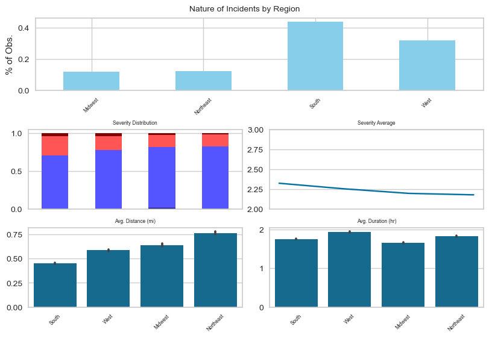

| Region | Severity | Time_of_Impact(hr) | Distance(mi) |
| --- | --- | --- | --- |
| Midwest | 2.323 | 1.659 | 0.639 |
| Northeast | 2.253 | 1.832 | 0.763 |
| South | 2.196 | 1.752 | 0.453 |
| West | 2.177 | 1.937 | 0.585 |

```python
reports,stats = test_results('Region',data);
data.groupby('Region')[['Severity','Time_of_Impact(hr)','Distance(mi)']].mean()
```

```
Based on the ANOVA test's p-value of 0.000, we reject the null hypothesis that there is no significant difference in incident duration across different SubRegions.
Based on the ANOVA test's p-value of 0.000, we reject the null hypothesis that there is no significant difference in incident distance across different SubRegions.
Based on the CHI-Squared test's p-value of 0.000, we reject the null hypothesis that there is no significant difference in incident severity across different SubRegions.
```

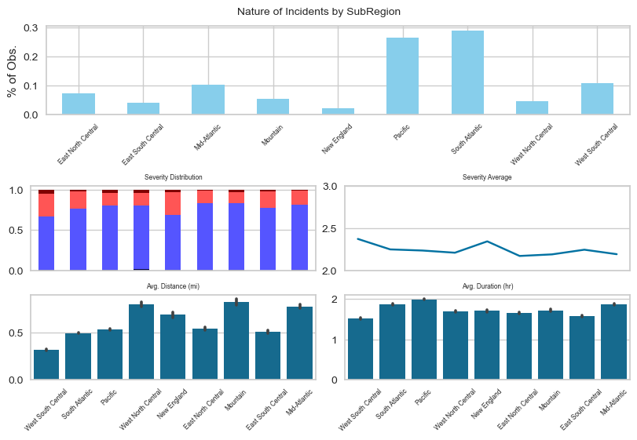

| SubRegion | Severity | Time_of_Impact(hr) | Distance(mi) |
| --- | --- | --- | --- |
| East North Central | 2.372 | 1.643 | 0.540 |
| East South Central | 2.248 | 1.574 | 0.509 |
| Mid-Atlantic | 2.235 | 1.858 | 0.778 |
| Mountain | 2.209 | 1.715 | 0.825 |
| New England | 2.343 | 1.701 | 0.689 |
| Pacific | 2.171 | 1.984 | 0.535 |
| South Atlantic | 2.189 | 1.865 | 0.497 |
| West North Central | 2.245 | 1.687 | 0.800 |
| West South Central | 2.192 | 1.520 | 0.315 |

```python
reports,stats = test_results('SubRegion',data);
data.groupby('SubRegion')[['Severity','Time_of_Impact(hr)','Distance(mi)']].mean()
```

```
Based on the ANOVA test's p-value of 0.000, we reject the null hypothesis that there is no significant difference in incident duration across different AA_Regions.
Based on the ANOVA test's p-value of 0.000, we reject the null hypothesis that there is no significant difference in incident distance across different AA_Regions.
Based on the CHI-Squared test's p-value of 0.000, we reject the null hypothesis that there is no significant difference in incident severity across different AA_Regions.
```

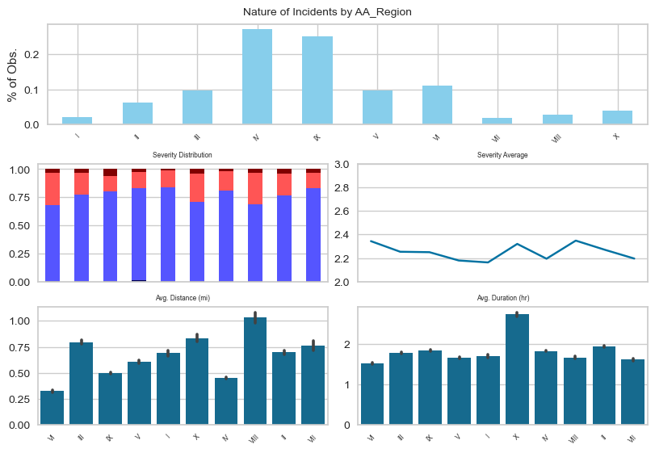

| AA_Region | Severity | Time_of_Impact(hr) | Distance(mi) |
| --- | --- | --- | --- |
| I | 2.343 | 1.701 | 0.689 |
| II | 2.253 | 1.939 | 0.698 |
| III | 2.250 | 1.785 | 0.795 |
| IV | 2.179 | 1.829 | 0.451 |
| IX | 2.163 | 1.845 | 0.497 |
| V | 2.320 | 1.667 | 0.607 |
| VI | 2.194 | 1.522 | 0.324 |
| VII | 2.348 | 1.615 | 0.763 |
| VIII | 2.269 | 1.668 | 1.030 |
| X | 2.196 | 2.739 | 0.835 |

```python
reports,stats = test_results('AA_Region',data)
data.groupby('AA_Region')[['Severity','Time_of_Impact(hr)','Distance(mi)']].mean()
```

```
Based on the ANOVA test's p-value of 0.000, we reject the null hypothesis that there is no significant difference in incident duration across different BEA_Regions.
Based on the ANOVA test's p-value of 0.000, we reject the null hypothesis that there is no significant difference in incident distance across different BEA_Regions.
Based on the CHI-Squared test's p-value of 0.000, we reject the null hypothesis that there is no significant difference in incident severity across different BEA_Regions.
```

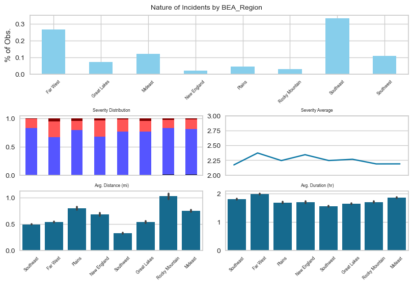

| BEA_Region | Severity | Time_of_Impact(hr) | Distance(mi) |
| --- | --- | --- | --- |
| Far West | 2.171 | 1.986 | 0.538 |
| Great Lakes | 2.372 | 1.643 | 0.540 |
| Mideast | 2.244 | 1.858 | 0.752 |
| New England | 2.343 | 1.701 | 0.689 |
| Plains | 2.245 | 1.687 | 0.800 |
| Rocky Mountain | 2.266 | 1.705 | 1.027 |
| Southeast | 2.188 | 1.807 | 0.495 |
| Southwest | 2.189 | 1.550 | 0.324 |

```python
reports,stats = test_results('BEA_Region',data)
data.groupby('BEA_Region')[['Severity','Time_of_Impact(hr)','Distance(mi)']].mean()
```

### By State

```python
states = data['State'].unique()

for state in states:
    print(state + ':')
    data['inState'] = data['State'] == state
    test_results('inState',data,visuals=False)
    print('-'*75)
```

```
LA:
Based on the ANOVA test's p-value of 0.000, we reject the null hypothesis that there is no significant difference in incident duration across different inStates.
Based on the ANOVA test's p-value of 0.000, we reject the null hypothesis that there is no significant difference in incident distance across different inStates.
Based on the CHI-Squared test's p-value of 0.000, we reject the null hypothesis that there is no significant difference in incident severity across different inStates.
---------------------------------------------------------------------------
VA:
Based on the ANOVA test's p-value of 0.000, we reject the null hypothesis that there is no significant difference in incident duration across different inStates.
Based on the ANOVA test's p-value of 0.000, we reject the null hypothesis that there is no significant difference in incident distance across different inStates.
Based on the CHI-Squared test's p-value of 0.000, we reject the null hypothesis that there is no significant difference in incident severity across different inStates.
---------------------------------------------------------------------------
CA:
Based on the ANOVA test's p-value of 0.000, we reject the null hypothesis that there is no significant difference in incident duration across different inStates.
Based on the ANOVA test's p-value of 0.000, we reject the null hypothesis that there is no significant difference in incident distance across different inStates.
Based on the CHI-Squared test's p-value of 0.000, we reject the null hypothesis that there is no significant difference in incident severity across different inStates.
---------------------------------------------------------------------------
MN:
Based on the ANOVA test's p-value of 0.000, we reject the null hypothesis that there is no significant difference in incident duration across different inStates.
Based on the ANOVA test's p-value of 0.000, we reject the null hypothesis that there is no significant difference in incident distance across different inStates.
Based on the CHI-Squared test's p-value of 0.000, we reject the null hypothesis that there is no significant difference in incident severity across different inStates.
---------------------------------------------------------------------------
MA:
Based on the ANOVA test's p-value of 0.000, we reject the null hypothesis that there is no significant difference in incident duration across different inStates.
Based on the ANOVA test's p-value of 0.000, we reject the null hypothesis that there is no significant difference in incident distance across different inStates.
Based on the CHI-Squared test's p-value of 0.000, we reject the null hypothesis that there is no significant difference in incident severity across different inStates.
---------------------------------------------------------------------------
OR:
Based on the ANOVA test's p-value of 0.000, we reject the null hypothesis that there is no significant difference in incident duration across different inStates.
Based on the ANOVA test's p-value of 0.000, we reject the null hypothesis that there is no significant difference in incident distance across different inStates.
Based on the CHI-Squared test's p-value of 0.000, we reject the null hypothesis that there is no significant difference in incident severity across different inStates.
---------------------------------------------------------------------------
FL:
Based on the ANOVA test's p-value of 0.000, we reject the null hypothesis that there is no significant difference in incident duration across different inStates.
Based on the ANOVA test's p-value of 0.000, we reject the null hypothesis that there is no significant difference in incident distance across different inStates.
Based on the CHI-Squared test's p-value of 0.000, we reject the null hypothesis that there is no significant difference in incident severity across different inStates.
---------------------------------------------------------------------------
TX:
Based on the ANOVA test's p-value of 0.000, we reject the null hypothesis that there is no significant difference in incident duration across different inStates.
Based on the ANOVA test's p-value of 0.000, we reject the null hypothesis that there is no significant difference in incident distance across different inStates.
Based on the CHI-Squared test's p-value of 0.000, we reject the null hypothesis that there is no significant difference in incident severity across different inStates.
---------------------------------------------------------------------------
```

[output cut: 190 more lines]

```
ME:
Based on the ANOVA test's p-value of 0.000, we reject the null hypothesis that there is no significant difference in incident duration across different inStates.
Based on the ANOVA test's p-value of 0.000, we reject the null hypothesis that there is no significant difference in incident distance across different inStates.
Based on the CHI-Squared test's p-value of 0.011, we fail to reject the null hypothesis that there is no significant difference in incident severity across different inStates.
---------------------------------------------------------------------------
ND:
Based on the ANOVA test's p-value of 0.770, we fail to reject the null hypothesis that there is no significant difference in incident duration across different inStates.
Based on the ANOVA test's p-value of 0.000, we reject the null hypothesis that there is no significant difference in incident distance across different inStates.
Based on the CHI-Squared test's p-value of 0.000, we reject the null hypothesis that there is no significant difference in incident severity across different inStates.
---------------------------------------------------------------------------
SD:
Based on the ANOVA test's p-value of 0.000, we reject the null hypothesis that there is no significant difference in incident duration across different inStates.
Based on the ANOVA test's p-value of 0.000, we reject the null hypothesis that there is no significant difference in incident distance across different inStates.
Based on the CHI-Squared test's p-value of 0.000, we reject the null hypothesis that there is no significant difference in incident severity across different inStates.
---------------------------------------------------------------------------
```

```python
data.groupby('State')[['Severity','Time_of_Impact(hr)','Distance(mi)']].mean()
```

| State | Severity | Time_of_Impact(hr) | Distance(mi) |
| --- | --- | --- | --- |
| AL | 2.244 | 1.441 | 0.453 |
| AR | 2.268 | 1.750 | 1.454 |
| AZ | 2.118 | 1.671 | 0.549 |
| CA | 2.166 | 1.858 | 0.488 |
| CO | 2.427 | 1.510 | 0.843 |
| CT | 2.361 | 2.161 | 1.124 |
| DC | 2.110 | 1.998 | 0.375 |
| DE | 2.276 | 1.512 | 0.470 |
| FL | 2.140 | 2.173 | 0.522 |
| GA | 2.501 | 1.595 | 0.628 |
| IA | 2.422 | 1.724 | 1.841 |
| ID | 2.127 | 2.623 | 1.353 |
| IL | 2.385 | 1.718 | 0.394 |
| IN | 2.399 | 1.774 | 1.056 |
| KS | 2.298 | 1.823 | 0.957 |
| KY | 2.438 | 1.395 | 0.399 |
| LA | 2.129 | 1.499 | 0.414 |
| MA | 2.306 | 1.081 | 0.261 |
| MD | 2.324 | 1.872 | 0.665 |
| ME | 2.191 | 2.445 | 1.132 |
| MI | 2.335 | 1.496 | 0.457 |
| MN | 2.168 | 1.736 | 0.803 |
| MO | 2.402 | 1.749 | 0.499 |
| MS | 2.359 | 1.867 | 0.679 |
| MT | 2.032 | 2.045 | 2.249 |
| NC | 2.130 | 1.792 | 0.288 |
| ND | 2.010 | 1.854 | 2.157 |
| NE | 2.174 | 1.050 | 0.373 |
| NH | 2.249 | 2.136 | 0.533 |
| NJ | 2.241 | 1.943 | 0.616 |
| NM | 2.406 | 1.714 | 1.055 |
| NV | 2.238 | 2.167 | 0.792 |
| NY | 2.258 | 1.937 | 0.730 |
| OH | 2.351 | 1.564 | 0.551 |
| OK | 2.076 | 1.087 | 0.076 |
| OR | 2.113 | 3.143 | 1.030 |
| PA | 2.204 | 1.727 | 0.909 |
| RI | 2.479 | 1.489 | 0.245 |
| SC | 2.111 | 1.397 | 0.305 |
| SD | 2.588 | 4.183 | 2.781 |
| TN | 2.205 | 1.662 | 0.549 |
| TX | 2.222 | 1.578 | 0.281 |
| UT | 2.189 | 1.681 | 0.716 |
| VA | 2.278 | 1.720 | 0.759 |
| VT | 2.364 | 2.082 | 2.051 |
| WA | 2.336 | 2.093 | 0.471 |
| WI | 2.494 | 1.979 | 0.625 |
| WV | 2.165 | 3.777 | 1.076 |
| WY | 2.345 | 2.070 | 3.199 |

### Federal Roads

```
Based on the ANOVA test's p-value of 0.000, we reject the null hypothesis that there is no significant difference in incident duration across different Federals.
Based on the ANOVA test's p-value of 0.000, we reject the null hypothesis that there is no significant difference in incident distance across different Federals.
Based on the CHI-Squared test's p-value of 0.000, we reject the null hypothesis that there is no significant difference in incident severity across different Federals.
```

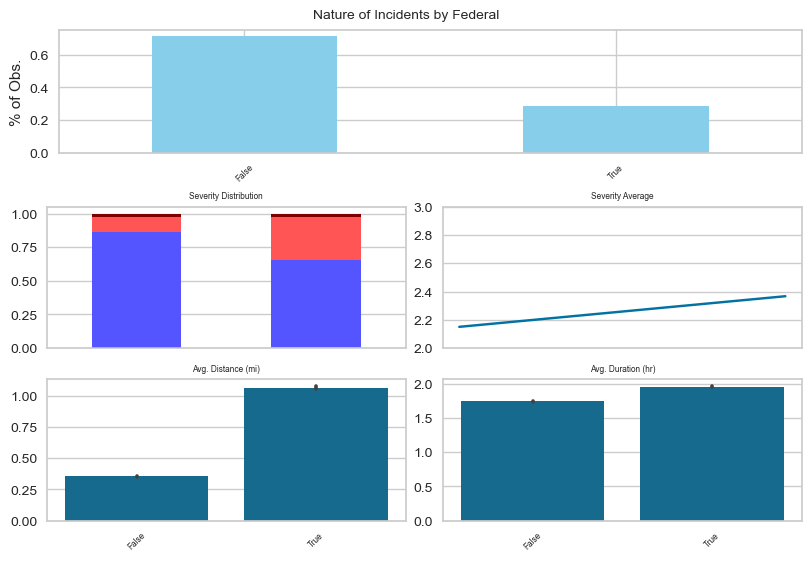

| Federal | Severity | Time_of_Impact(hr) | Distance(mi) |
| --- | --- | --- | --- |
| False | 2.150 | 1.750 | 0.353 |
| True | 2.367 | 1.960 | 1.065 |

```python
reports,stats = test_results('Federal',data)
data.groupby('Federal')[['Severity','Time_of_Impact(hr)','Distance(mi)']].mean()
```

```
Based on the ANOVA test's p-value of 0.002, we reject the null hypothesis that there is no significant difference in incident duration across different Bridges.
Based on the ANOVA test's p-value of 0.000, we reject the null hypothesis that there is no significant difference in incident distance across different Bridges.
Based on the CHI-Squared test's p-value of 0.000, we reject the null hypothesis that there is no significant difference in incident severity across different Bridges.
```

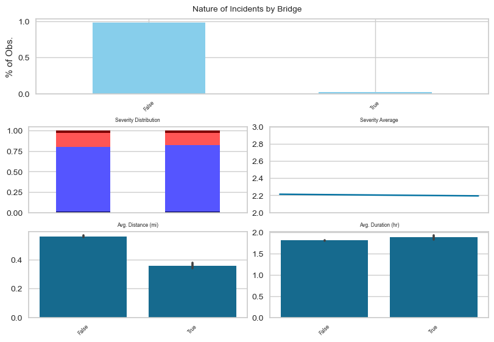

| Bridge | Severity | Time_of_Impact(hr) | Distance(mi) |
| --- | --- | --- | --- |
| False | 2.212 | 1.809 | 0.559 |
| True | 2.193 | 1.876 | 0.358 |

```python
reports,stats = test_results('Bridge',data)
data.groupby('Bridge')[['Severity','Time_of_Impact(hr)','Distance(mi)']].mean()
```

### Infrastructure

```python
infrastructures = ['Amenity','Bump','Crossing','Give_Way',
                   'Junction','No_Exit','Railway','Roundabout',
                   'Station','Stop','Traffic_Calming','Traffic_Signal',
                   'Turning_Loop'
                   ]
```

```python
if _SPARK_:
    spark = SparkSession.builder.appName("Accident Data Project").getOrCreate()
    data = spark.read.csv('AccidentData_Clean.csv',header=True,inferSchema=True)
else:
    if _LITE_SWITCH_:
        data = pd.read_csv('AccidentData_Sampled_Clean.csv')
    else:
        data = pd.read_csv('AccidentData_Clean.csv',usecols = infrastructures + ['Severity','Distance(mi)','Time_of_Impact(hr)'])
```

```python
for structure in infrastructures:
    if data[structure].sum() > 0:
        print(structure+": ")
        reports,stats = test_results(structure,data,visuals=False)
        display(data.groupby(structure)[['Severity','Time_of_Impact(hr)','Distance(mi)']].mean())
        print('-'*75)
    else:
        pass
```

```
Amenity:
Based on the ANOVA test's p-value of 0.002, we reject the null hypothesis that there is no significant difference in incident duration across different Amenitys.
Based on the ANOVA test's p-value of 0.000, we reject the null hypothesis that there is no significant difference in incident distance across different Amenitys.
Based on the CHI-Squared test's p-value of 0.000, we reject the null hypothesis that there is no significant difference in incident severity across different Amenitys.
```

| Amenity | Severity | Time_of_Impact(hr) | Distance(mi) |
| --- | --- | --- | --- |
| False | 2.214 | 1.811 | 0.561 |
| True | 2.071 | 1.726 | 0.123 |

```
---------------------------------------------------------------------------
Bump:
Based on the ANOVA test's p-value of 0.766, we fail to reject the null hypothesis that there is no significant difference in incident duration across different Bumps.
Based on the ANOVA test's p-value of 0.007, we reject the null hypothesis that there is no significant difference in incident distance across different Bumps.
Based on the CHI-Squared test's p-value of 0.041, we fail to reject the null hypothesis that there is no significant difference in incident severity across different Bumps.
```

| Bump | Severity | Time_of_Impact(hr) | Distance(mi) |
| --- | --- | --- | --- |
| False | 2.212 | 1.810 | 0.555 |
| True | 2.134 | 1.767 | 0.242 |

```
---------------------------------------------------------------------------
Crossing:
Based on the ANOVA test's p-value of 0.000, we reject the null hypothesis that there is no significant difference in incident duration across different Crossings.
Based on the ANOVA test's p-value of 0.000, we reject the null hypothesis that there is no significant difference in incident distance across different Crossings.
Based on the CHI-Squared test's p-value of 0.000, we reject the null hypothesis that there is no significant difference in incident severity across different Crossings.
```

| Crossing | Severity | Time_of_Impact(hr) | Distance(mi) |
| --- | --- | --- | --- |
| False | 2.231 | 1.833 | 0.612 |
| True | 2.064 | 1.629 | 0.113 |

```
---------------------------------------------------------------------------
Give_Way:
Based on the ANOVA test's p-value of 0.000, we reject the null hypothesis that there is no significant difference in incident duration across different Give_Ways.
Based on the ANOVA test's p-value of 0.000, we reject the null hypothesis that there is no significant difference in incident distance across different Give_Ways.
Based on the CHI-Squared test's p-value of 0.000, we reject the null hypothesis that there is no significant difference in incident severity across different Give_Ways.
```

| Give_Way | Severity | Time_of_Impact(hr) | Distance(mi) |
| --- | --- | --- | --- |
| False | 2.212 | 1.811 | 0.556 |
| True | 2.182 | 1.610 | 0.340 |

```
---------------------------------------------------------------------------
Junction:
Based on the ANOVA test's p-value of 0.000, we reject the null hypothesis that there is no significant difference in incident duration across different Junctions.
Based on the ANOVA test's p-value of 0.000, we reject the null hypothesis that there is no significant difference in incident distance across different Junctions.
Based on the CHI-Squared test's p-value of 0.000, we reject the null hypothesis that there is no significant difference in incident severity across different Junctions.
```

| Junction | Severity | Time_of_Impact(hr) | Distance(mi) |
| --- | --- | --- | --- |
| False | 2.205 | 1.781 | 0.540 |
| True | 2.302 | 2.173 | 0.752 |

```
---------------------------------------------------------------------------
No_Exit:
Based on the ANOVA test's p-value of 0.164, we fail to reject the null hypothesis that there is no significant difference in incident duration across different No_Exits.
Based on the ANOVA test's p-value of 0.000, we reject the null hypothesis that there is no significant difference in incident distance across different No_Exits.
Based on the CHI-Squared test's p-value of 0.000, we reject the null hypothesis that there is no significant difference in incident severity across different No_Exits.
```

| No_Exit | Severity | Time_of_Impact(hr) | Distance(mi) |
| --- | --- | --- | --- |
| False | 2.212 | 1.810 | 0.556 |
| True | 2.131 | 1.894 | 0.219 |

```
---------------------------------------------------------------------------
Railway:
Based on the ANOVA test's p-value of 0.001, we reject the null hypothesis that there is no significant difference in incident duration across different Railways.
Based on the ANOVA test's p-value of 0.000, we reject the null hypothesis that there is no significant difference in incident distance across different Railways.
Based on the CHI-Squared test's p-value of 0.000, we reject the null hypothesis that there is no significant difference in incident severity across different Railways.
```

| Railway | Severity | Time_of_Impact(hr) | Distance(mi) |
| --- | --- | --- | --- |
| False | 2.213 | 1.811 | 0.558 |
| True | 2.152 | 1.701 | 0.226 |

```
---------------------------------------------------------------------------
Roundabout:
Based on the ANOVA test's p-value of 0.634, we fail to reject the null hypothesis that there is no significant difference in incident duration across different Roundabouts.
Based on the ANOVA test's p-value of 0.354, we fail to reject the null hypothesis that there is no significant difference in incident distance across different Roundabouts.
Based on the CHI-Squared test's p-value of 0.344, we fail to reject the null hypothesis that there is no significant difference in incident severity across different Roundabouts.
```

| Roundabout | Severity | Time_of_Impact(hr) | Distance(mi) |
| --- | --- | --- | --- |
| False | 2.212 | 1.810 | 0.555 |
| True | 2.000 | 1.533 | 0.121 |

```
---------------------------------------------------------------------------
Station:
Based on the ANOVA test's p-value of 0.000, we reject the null hypothesis that there is no significant difference in incident duration across different Stations.
Based on the ANOVA test's p-value of 0.000, we reject the null hypothesis that there is no significant difference in incident distance across different Stations.
Based on the CHI-Squared test's p-value of 0.000, we reject the null hypothesis that there is no significant difference in incident severity across different Stations.
```

| Station | Severity | Time_of_Impact(hr) | Distance(mi) |
| --- | --- | --- | --- |
| False | 2.216 | 1.806 | 0.567 |
| True | 2.075 | 1.965 | 0.132 |

```
---------------------------------------------------------------------------
Stop:
Based on the ANOVA test's p-value of 0.000, we reject the null hypothesis that there is no significant difference in incident duration across different Stops.
Based on the ANOVA test's p-value of 0.000, we reject the null hypothesis that there is no significant difference in incident distance across different Stops.
Based on the CHI-Squared test's p-value of 0.000, we reject the null hypothesis that there is no significant difference in incident severity across different Stops.
```

| Stop | Severity | Time_of_Impact(hr) | Distance(mi) |
| --- | --- | --- | --- |
| False | 2.216 | 1.815 | 0.565 |
| True | 2.074 | 1.652 | 0.223 |

```
---------------------------------------------------------------------------
Traffic_Calming:
Based on the ANOVA test's p-value of 0.417, we fail to reject the null hypothesis that there is no significant difference in incident duration across different Traffic_Calmings.
Based on the ANOVA test's p-value of 0.000, we reject the null hypothesis that there is no significant difference in incident distance across different Traffic_Calmings.
Based on the CHI-Squared test's p-value of 0.002, we reject the null hypothesis that there is no significant difference in incident severity across different Traffic_Calmings.
```

| Traffic_Calming | Severity | Time_of_Impact(hr) | Distance(mi) |
| --- | --- | --- | --- |
| False | 2.212 | 1.810 | 0.556 |
| True | 2.136 | 1.730 | 0.222 |

```
---------------------------------------------------------------------------
Traffic_Signal:
Based on the ANOVA test's p-value of 0.000, we reject the null hypothesis that there is no significant difference in incident duration across different Traffic_Signals.
Based on the ANOVA test's p-value of 0.000, we reject the null hypothesis that there is no significant difference in incident distance across different Traffic_Signals.
Based on the CHI-Squared test's p-value of 0.000, we reject the null hypothesis that there is no significant difference in incident severity across different Traffic_Signals.
```

| Traffic_Signal | Severity | Time_of_Impact(hr) | Distance(mi) |
| --- | --- | --- | --- |
| False | 2.234 | 1.886 | 0.635 |
| True | 2.089 | 1.380 | 0.102 |

# 7-Advanced Analysis

## Possible

### Statistical Analyses with Subsets of Data

State-by-State

County-by-County

Year-by-Year

### Other

Interstate

Frequent Coordinates

```python
coords_count = data.value_counts(['Start_Lat','Start_Lng'])
coords_count = coords_count[coords_count > 30].reset_index()
```

```python
lat,lng = coords_count.loc[0][['Start_Lat','Start_Lng']]
same_spot = data[(data['Start_Lat']==lat) & (data['Start_Lng']==lng)]
```

```python
same_spot.Weather_Condition.value_counts()
```

```
Weather_Condition
Fair                       25
Cloudy                      6
Mostly Cloudy               6
Heavy Rain                  2
Light Rain                  2
Partly Cloudy               1
Fog                         1
Thunder in the Vicinity     1
Name: count, dtype: int64
```

```python
same_spot[infrastructures].sum()
```

```
Amenity            0
Bump               0
Crossing           0
Give_Way           0
Junction           0
No_Exit            0
Railway            0
Roundabout         0
Station            0
Stop               0
Traffic_Calming    0
Traffic_Signal     0
Turning_Loop       0
dtype: int64
```

```python
same_spot['Severity'].value_counts()
```

```
Severity
2    30
3    12
1     2
Name: count, dtype: int64
```

```python
same_spot[['Year','Month']].value_counts().sort_index()
```

```
Year  Month
2020  4        1
      6        1
      7        1
      8        1
      9        1
      10       3
      11       1
      12       2
2021  1        1
      2        2
      3        2
      5        3
      6        2
      7        3
      8        1
      9        2
      10       1
      11       1
      12       1
2022  2        2
      4        2
      6        1
      7        1
      8        6
      9        2
Name: count, dtype: int64
```

```python
same_spot[['DayofWeek','Hour']].value_counts().sort_index()
```

```
DayofWeek  Hour
0          7       3
           16      1
           17      4
           19      1
1          6       1
           8       2
           10      1
           12      1
           19      1
           23      1
2          5       1
           12      1
           14      1
           17      2
```

[output cut: 20 more lines]

Commute Data (By State/County)

DBScan on Clustering

Interstate

Infrastructure Cooccurence

## Wish List

### Unusual Weather

Does driving in unexpected weather--based on area, time of year and/or both--create a higher likelihood of an accident.

### Highway's Near Urban Areas

For cross-state

### Naturual Language

Examination of the description feature.

### Safety Infrastructure

Does certain road infrastructure projects help reduce the number of incidents?

### New Traffic Pattern

Does the existence of a new traffic pattern in the area increase the likelihood of an accident?

### Recent Accident Indicator

Does the presence of one accident, predict another.

# 7-Insights & Conclusions

## Basic Insights

### Annual Distinctions

Number of Accidents; Distribution of Severities; Length of Impact

```python
data['State'].value_counts()
```

```
State
CA    109317
FL     55013
TX     36497
SC     24083
NY     22222
NC     21354
PA     18706
VA     18016
MN     12082
OR     11257
IL     10798
GA     10775
TN     10760
AZ     10638
MI     10451
LA      9514
NJ      8467
OH      7565
MD      7233
WA      6922
AL      6441
CO      5755
UT      5737
OK      5225
MO      4752
CT      4556
IN      4196
MA      3713
WI      2261
KY      2072
NE      1866
MT      1759
IA      1631
AR      1369
NV      1324
KS      1156
DC      1132
RI      1051
MS       949
DE       887
WV       818
ID       639
NM       623
NH       615
WY       223
ME       199
ND       193
VT        55
SD        17
Name: count, dtype: int64
```

### Temporal & Spatial Considerations

How do accident counts relate to different times of the day and for different region types (urban vs rural)?

### Weather Considerations

Does certain weather conditions produce more severe incidents?

# Advanced (Wish List) Analysis

## Unusual Weather

Does driving in unexpected weather--based on area, time of year and/or both--create a higher likelihood of an accident.

## Highway's Near Urban Areas

For cross-state

## Naturual Language

Examination of the description feature.

## Safety Infrastructure

Does certain road infrastructure projects help reduce the number of incidents?

## New Traffic Pattern

Does the existence of a new traffic pattern in the area increase the likelihood of an accident?

## Recent Accident Indicator

Does the presence of one accident, predict another.